# Entrega1

Ángel Sánchez Sanjuán

31 de diciembre de 2016

## 1. Introducción

Aunque la práctica se refiera únicamente a llevar a cabo un análsis descriptivo y exploratorio de los datos, nos anima también a propornernos una pregunta para un anásis posterior más avanzado.

En mi caso y tras leer el paper de Cortez & Silva, me planteo la siguiente pregunta: ¿ Tendrá infleuncia el entorno del alumno en las notas finales?, es decir, ¿tendrá algún efecto en las notas que el entorno del alumo sea rural o urbano?.

A lo largo de ambos análisis, espero poder llegar al menos a la conclusión de si los datos nos permitirían llevar a cabo el análisis pretendido.

## 2. Carga de los datos

### 2.1 Preparación del entorno

```r
knitr::opts_chunk$set(echo = TRUE)

library(knitr)
library(ggplot2)

getwd()
```

```
## [1] "/home/angel/repositorios/BIGDATAUPSA"
```

```r
workingdirectory <- getwd()

## setwd(workingdirectory/Entrega1Angel)


if (!file.exists("datos")) {
  dir.create("datos")
}
```

### 2.2 Descarga de datos

Una vez hemos preparado el entorno, procedemos a la descarga de los datos de internet

```r
fileUrl <- "https://archive.ics.uci.edu/ml/machine-learning-databases/00320/student.zip"
download.file(fileUrl,destfile="./datos/student.zip", method="curl")
unzip("./datos/student.zip", exdir="./datos")
list.files("./datos")
```

```
## [1] "student-mat.csv" "student-merge.R" "student-por.csv" "student.txt"
## [5] "student.zip"
```

Una vez descargado, eliminamos el enlace y guardamos la fecha de descarga

```r
rm(fileUrl)
fechaDescarga <- date()
fechaDescarga
```

```
## [1] "Sat Dec 31 13:31:28 2016"
```

### 2.3 Preparamos los datos

Leemos los datos de los archivos

```r
studentMat <- read.table("./datos/student-mat.csv",
                         row.names=NULL, sep=";", header=TRUE)

studentPor <- read.table("./datos/student-por.csv",
                         row.names=NULL, sep=";", header=TRUE)
```

Creamos una copia para trabajar con ellos

```r
studentMatTra <- studentMat

studentPorTra <- studentPor
```

Unimos ambos datasets para tener datos de los estudiantes que hicieron ambas asignaturas

```r
studentMatPorTra <- merge(studentMatTra,studentPorTra,
                       by=c("school","sex","age",
                            "address","famsize",
                            "Pstatus","Medu",
                            "Fedu","Mjob",
                            "Fjob","reason",
                            "nursery","internet"),
                       all=FALSE,
                       suffixes=c("mat","por"))
dim(studentMatPorTra)[1]
```

```
## [1] 382
```

```r
head(studentMatPorTra)
```

```
##   school sex age address famsize Pstatus Medu Fedu     Mjob     Fjob
## 1     GP   F  15       R     GT3       T    1    1  at_home    other
## 2     GP   F  15       R     GT3       T    1    1    other    other
## 3     GP   F  15       R     GT3       T    2    2  at_home    other
## 4     GP   F  15       R     GT3       T    2    4 services   health
## 5     GP   F  15       R     GT3       T    3    3 services services
## 6     GP   F  15       R     GT3       T    3    4 services   health
##       reason nursery internet guardianmat traveltimemat studytimemat
## 1       home     yes      yes      mother             2            4
## 2 reputation      no      yes      mother             1            2
## 3 reputation     yes       no      mother             1            1
## 4     course     yes      yes      mother             1            3
## 5 reputation     yes      yes       other             2            3
## 6     course     yes      yes      mother             1            3
##   failuresmat schoolsupmat famsupmat paidmat activitiesmat highermat
```

[output cut: 41 more lines]

## 3. Análisis Descriptivo

Estudiaremos en primer lugar la media, mediana, etc. del dataset

```r
summary(studentMatPorTra)
```

```
##  school   sex          age        address famsize   Pstatus
##  GP:342   F:198   Min.   :15.00   R: 81   GT3:278   A: 38
##  MS: 40   M:184   1st Qu.:16.00   U:301   LE3:104   T:344
##                   Median :17.00
##                   Mean   :16.59
##                   3rd Qu.:17.00
##                   Max.   :22.00
##       Medu            Fedu             Mjob           Fjob
##  Min.   :0.000   Min.   :0.000   at_home : 53   at_home : 16
##  1st Qu.:2.000   1st Qu.:2.000   health  : 33   health  : 17
##  Median :3.000   Median :3.000   other   :138   other   :211
##  Mean   :2.806   Mean   :2.565   services: 96   services:107
##  3rd Qu.:4.000   3rd Qu.:4.000   teacher : 62   teacher : 31
##  Max.   :4.000   Max.   :4.000
##         reason    nursery   internet  guardianmat  traveltimemat
##  course    :140   no : 72   no : 58   father: 91   Min.   :1.000
##  home      :110   yes:310   yes:324   mother:275   1st Qu.:1.000
##  other     : 34                       other : 16   Median :1.000
##  reputation: 98                                    Mean   :1.442
##                                                    3rd Qu.:2.000
##                                                    Max.   :4.000
##   studytimemat    failuresmat     schoolsupmat famsupmat paidmat
##  Min.   :1.000   Min.   :0.0000   no :331      no :144   no :205
##  1st Qu.:1.000   1st Qu.:0.0000   yes: 51      yes:238   yes:177
##  Median :2.000   Median :0.0000
##  Mean   :2.034   Mean   :0.2906
##  3rd Qu.:2.000   3rd Qu.:0.0000
##  Max.   :4.000   Max.   :3.0000
##  activitiesmat highermat romanticmat   famrelmat     freetimemat
##  no :181       no : 18   no :261     Min.   :1.00   Min.   :1.000
##  yes:201       yes:364   yes:121     1st Qu.:4.00   1st Qu.:3.000
##                                      Median :4.00   Median :3.000
##                                      Mean   :3.94   Mean   :3.223
##                                      3rd Qu.:5.00   3rd Qu.:4.000
##                                      Max.   :5.00   Max.   :5.000
##     gooutmat        Dalcmat         Walcmat       healthmat
##  Min.   :1.000   Min.   :1.000   Min.   :1.00   Min.   :1.000
##  1st Qu.:2.000   1st Qu.:1.000   1st Qu.:1.00   1st Qu.:3.000
##  Median :3.000   Median :1.000   Median :2.00   Median :4.000
##  Mean   :3.113   Mean   :1.474   Mean   :2.28   Mean   :3.579
```

[output cut: 29 more lines]

```
##  Max.   :5.000   Max.   :5.00   Max.   :5.000   Max.   :5.000
##     Walcpor        healthpor      absencespor         G1por
##  Min.   :1.000   Min.   :1.000   Min.   : 0.000   Min.   : 0.00
##  1st Qu.:1.000   1st Qu.:3.000   1st Qu.: 0.000   1st Qu.:10.00
##  Median :2.000   Median :4.000   Median : 2.000   Median :12.00
##  Mean   :2.291   Mean   :3.576   Mean   : 3.673   Mean   :12.11
##  3rd Qu.:3.000   3rd Qu.:5.000   3rd Qu.: 6.000   3rd Qu.:14.00
##  Max.   :5.000   Max.   :5.000   Max.   :32.000   Max.   :19.00
##      G2por           G3por
##  Min.   : 5.00   Min.   : 0.00
##  1st Qu.:11.00   1st Qu.:11.00
##  Median :12.00   Median :13.00
##  Mean   :12.24   Mean   :12.52
##  3rd Qu.:14.00   3rd Qu.:14.00
##  Max.   :19.00   Max.   :19.00
```

Los clasificamos ahora en función de lo que queremos estudiar, la influencia del entorno rural o urbano

```r
studentMatPorTraUrb <- studentMatPorTra [studentMatPorTra$address == "U", ]

studentMatPorTraRur <- studentMatPorTra [studentMatPorTra$address == "R", ]
```

y estudiamos la media, mediana etc. de las notas de cada uno de los segmentos por separado

```r
RurG3mat <- summary(studentMatPorTraRur$G3mat)
RurG3por <- summary(studentMatPorTraRur$G3por)
UrbG3mat <- summary(studentMatPorTraUrb$G3mat)
UrbG3por <- summary(studentMatPorTraUrb$G3por)
G3mat <- summary(studentMatPorTra$G3mat)
G3por <- summary(studentMatPorTra$G3por)

RurG3mat
```

```
##    Min. 1st Qu.  Median    Mean 3rd Qu.    Max.
##   0.000   8.000  10.000   9.556  12.000  19.000
```

```r
RurG3por
```

```
##    Min. 1st Qu.  Median    Mean 3rd Qu.    Max.
##    0.00   10.00   11.00   11.44   13.00   19.00
```

```r
UrbG3mat
```

```
##    Min. 1st Qu.  Median    Mean 3rd Qu.    Max.
##    0.00    9.00   11.00   10.61   14.00   20.00
```

```r
UrbG3por
```

```
##    Min. 1st Qu.  Median    Mean 3rd Qu.    Max.
##     0.0    11.0    13.0    12.8    15.0    19.0
```

```r
G3mat
```

```
##    Min. 1st Qu.  Median    Mean 3rd Qu.    Max.
##    0.00    8.00   11.00   10.39   14.00   20.00
```

```r
G3por
```

```
##    Min. 1st Qu.  Median    Mean 3rd Qu.    Max.
##    0.00   11.00   13.00   12.52   14.00   19.00
```

## 4. Análisis Exploratorio

Para poder hacer más compresible y comparable los resultados obtenidos, utilizaremos un diagrama de cajas con los resultados

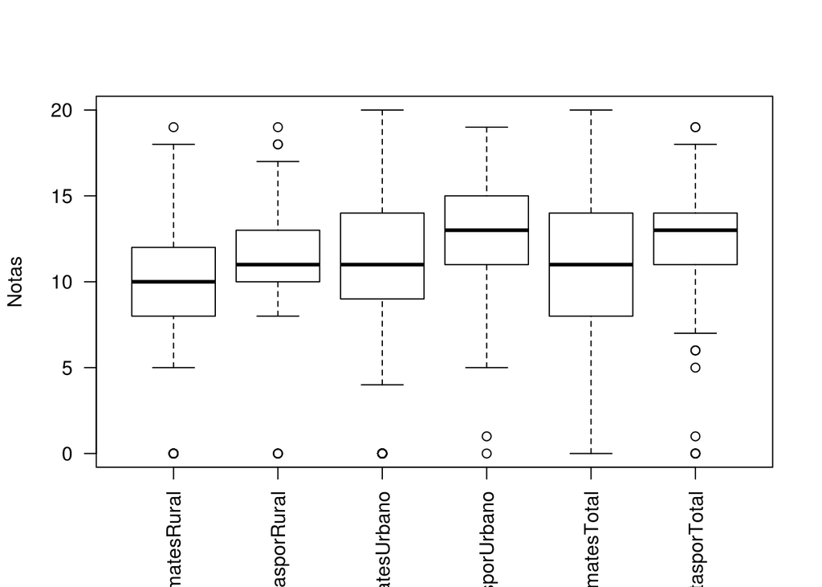

```r
boxplot(studentMatPorTraRur$G3mat, studentMatPorTraRur$G3por,
        studentMatPorTraUrb$G3mat, studentMatPorTraUrb$G3por,
        studentMatPorTra$G3mat, studentMatPorTra$G3por, las=2,
        names = c("NotasmatesRural", "NotasporRural",
                  "NotasmatesUrbano", "NotasporUrbano",
        "NotasmatesTotal", "NotasporTotal"), ylab = "Notas")
```

Nota: Sé que debía utilizar ggplot2 pero no supe como hacerlo :-)

## 5. Conclusiones

Como podemos ver, tanto observando el boxplot como analizando los datos obtenidos del summary de cada variable, las notas son de forma general menores en matematicas que en portugues, pero a la vez podemos ver como las notas son menores de forma general tanto en portugues como en matematicas entre los alumnos procedentes de entornos rurales y los alumnos procedentes de entornos urbanos.

El estudio de estos resultados preliminares como de su significacncia estadistica requeriría un estudio más amplio y minucioso.